# Project: Data Analyis of TMDb movie dataset (UDACITY)

*by Carla Mota Leal*

- Introduction
- Data Wrangling
- Exploratory Data Analysis
- Conclusions

## Introduction

> This data set contains information about 10000 movies collected from The Movie Database (TMDb), including user ratings and revenue.
- Certain columns, like ‘cast’ and ‘genres’, contain multiple values separated by pipe (|) characters.
- There are some odd characters in the ‘cast’ column. Don’t worry about cleaning them. You can leave them as is.
- The final two columns ending with “_adj” show the budget and revenue of the associated movie in terms of 2010 dollars, accounting for inflation over time.

```python
#loading necessary libraries

import pandas as pd
import numpy as np
import seaborn as sns
import matplotlib.pyplot as plt
%matplotlib inline
```

## Data Wrangling

> **Information from dataset**: There's 21 columns and 10866 entries, which 9 columns has different entries. In the column *imdb_id* they starts with 'tt'- characterized as obrject; In the column *cast*, *genres* and *production_companies*: the names are separeted by '|'; In the column *release_date*: needs to be converted to_datetime.

### General Properties

```python
# Load data

df = pd.read_csv('tmdb-movies.csv')

#Printing data columns
print(list(df.columns.values))
```

```
['id', 'imdb_id', 'popularity', 'budget', 'revenue', 'original_title', 'cast', 'homepage', 'director', 'tagline', 'keywords', 'overview', 'runtime', 'genres', 'production_companies', 'release_date', 'vote_count', 'vote_average', 'release_year', 'budget_adj', 'revenue_adj']
```

```python
#data info
df.info()
#float64(4), int64(6), object(11)
#10866 entries, 21 columns
```

```
<class 'pandas.core.frame.DataFrame'>
RangeIndex: 10866 entries, 0 to 10865
Data columns (total 21 columns):
 #   Column                Non-Null Count  Dtype
---  ------                --------------  -----
 0   id                    10866 non-null  int64
 1   imdb_id               10856 non-null  object
 2   popularity            10866 non-null  float64
 3   budget                10866 non-null  int64
 4   revenue               10866 non-null  int64
 5   original_title        10866 non-null  object
 6   cast                  10790 non-null  object
 7   homepage              2936 non-null   object
 8   director              10822 non-null  object
 9   tagline               8042 non-null   object
 10  keywords              9373 non-null   object
 11  overview              10862 non-null  object
 12  runtime               10866 non-null  int64
 13  genres                10843 non-null  object
 14  production_companies  9836 non-null   object
 15  release_date          10866 non-null  object
 16  vote_count            10866 non-null  int64
 17  vote_average          10866 non-null  float64
 18  release_year          10866 non-null  int64
 19  budget_adj            10866 non-null  float64
 20  revenue_adj           10866 non-null  float64
dtypes: float64(4), int64(6), object(11)
memory usage: 1.7+ MB
```

```python
#check the first 10 rows to observe how the dataset in composed

df.head(10)
```

|  | id | imdb_id | popularity | budget | revenue | original_title | cast | homepage | director | tagline | ... | overview | runtime | genres | production_companies | release_date | vote_count | vote_average | release_year | budget_adj | revenue_adj |
| --- | --- | --- | --- | --- | --- | --- | --- | --- | --- | --- | --- | --- | --- | --- | --- | --- | --- | --- | --- | --- | --- |
| 0 | 135397 | tt0369610 | 32.985763 | 150000000 | 1513528810 | Jurassic World | Chris Pratt\|Bryce Dallas Howard\|Irrfan Khan\|Vi... | http://www.jurassicworld.com/ | Colin Trevorrow | The park is open. | ... | Twenty-two years after the events of Jurassic ... | 124 | Action\|Adventure\|Science Fiction\|Thriller | Universal Studios\|Amblin Entertainment\|Legenda... | 6/9/15 | 5562 | 6.5 | 2015 | 1.379999e+08 | 1.392446e+09 |
| 1 | 76341 | tt1392190 | 28.419936 | 150000000 | 378436354 | Mad Max: Fury Road | Tom Hardy\|Charlize Theron\|Hugh Keays-Byrne\|Nic... | http://www.madmaxmovie.com/ | George Miller | What a Lovely Day. | ... | An apocalyptic story set in the furthest reach... | 120 | Action\|Adventure\|Science Fiction\|Thriller | Village Roadshow Pictures\|Kennedy Miller Produ... | 5/13/15 | 6185 | 7.1 | 2015 | 1.379999e+08 | 3.481613e+08 |
| 2 | 262500 | tt2908446 | 13.112507 | 110000000 | 295238201 | Insurgent | Shailene Woodley\|Theo James\|Kate Winslet\|Ansel... | http://www.thedivergentseries.movie/#insurgent | Robert Schwentke | One Choice Can Destroy You | ... | Beatrice Prior must confront her inner demons ... | 119 | Adventure\|Science Fiction\|Thriller | Summit Entertainment\|Mandeville Films\|Red Wago... | 3/18/15 | 2480 | 6.3 | 2015 | 1.012000e+08 | 2.716190e+08 |
| 3 | 140607 | tt2488496 | 11.173104 | 200000000 | 2068178225 | Star Wars: The Force Awakens | Harrison Ford\|Mark Hamill\|Carrie Fisher\|Adam D... | http://www.starwars.com/films/star-wars-episod... | J.J. Abrams | Every generation has a story. | ... | Thirty years after defeating the Galactic Empi... | 136 | Action\|Adventure\|Science Fiction\|Fantasy | Lucasfilm\|Truenorth Productions\|Bad Robot | 12/15/15 | 5292 | 7.5 | 2015 | 1.839999e+08 | 1.902723e+09 |
| 4 | 168259 | tt2820852 | 9.335014 | 190000000 | 1506249360 | Furious 7 | Vin Diesel\|Paul Walker\|Jason Statham\|Michelle ... | http://www.furious7.com/ | James Wan | Vengeance Hits Home | ... | Deckard Shaw seeks revenge against Dominic Tor... | 137 | Action\|Crime\|Thriller | Universal Pictures\|Original Film\|Media Rights ... | 4/1/15 | 2947 | 7.3 | 2015 | 1.747999e+08 | 1.385749e+09 |
| 5 | 281957 | tt1663202 | 9.110700 | 135000000 | 532950503 | The Revenant | Leonardo DiCaprio\|Tom Hardy\|Will Poulter\|Domhn... | http://www.foxmovies.com/movies/the-revenant | Alejandro González Iñárritu | (n. One who has returned, as if from the dead.) | ... | In the 1820s, a frontiersman, Hugh Glass, sets... | 156 | Western\|Drama\|Adventure\|Thriller | Regency Enterprises\|Appian Way\|CatchPlay\|Anony... | 12/25/15 | 3929 | 7.2 | 2015 | 1.241999e+08 | 4.903142e+08 |
| 6 | 87101 | tt1340138 | 8.654359 | 155000000 | 440603537 | Terminator Genisys | Arnold Schwarzenegger\|Jason Clarke\|Emilia Clar... | http://www.terminatormovie.com/ | Alan Taylor | Reset the future | ... | The year is 2029. John Connor, leader of the r... | 125 | Science Fiction\|Action\|Thriller\|Adventure | Paramount Pictures\|Skydance Productions | 6/23/15 | 2598 | 5.8 | 2015 | 1.425999e+08 | 4.053551e+08 |
| 7 | 286217 | tt3659388 | 7.667400 | 108000000 | 595380321 | The Martian | Matt Damon\|Jessica Chastain\|Kristen Wiig\|Jeff ... | http://www.foxmovies.com/movies/the-martian | Ridley Scott | Bring Him Home | ... | During a manned mission to Mars, Astronaut Mar... | 141 | Drama\|Adventure\|Science Fiction | Twentieth Century Fox Film Corporation\|Scott F... | 9/30/15 | 4572 | 7.6 | 2015 | 9.935996e+07 | 5.477497e+08 |
| 8 | 211672 | tt2293640 | 7.404165 | 74000000 | 1156730962 | Minions | Sandra Bullock\|Jon Hamm\|Michael Keaton\|Allison... | http://www.minionsmovie.com/ | Kyle Balda\|Pierre Coffin | Before Gru, they had a history of bad bosses | ... | Minions Stuart, Kevin and Bob are recruited by... | 91 | Family\|Animation\|Adventure\|Comedy | Universal Pictures\|Illumination Entertainment | 6/17/15 | 2893 | 6.5 | 2015 | 6.807997e+07 | 1.064192e+09 |
| 9 | 150540 | tt2096673 | 6.326804 | 175000000 | 853708609 | Inside Out | Amy Poehler\|Phyllis Smith\|Richard Kind\|Bill Ha... | http://movies.disney.com/inside-out | Pete Docter | Meet the little voices inside your head. | ... | Growing up can be a bumpy road, and it's no ex... | 94 | Comedy\|Animation\|Family | Walt Disney Pictures\|Pixar Animation Studios\|W... | 6/9/15 | 3935 | 8.0 | 2015 | 1.609999e+08 | 7.854116e+08 |

10 rows × 21 columns

```python
#summary descriptive data statistics
df.describe()
#in budget and revenue columns there's zeo values
```

|  | id | popularity | budget | revenue | runtime | vote_count | vote_average | release_year | budget_adj | revenue_adj |
| --- | --- | --- | --- | --- | --- | --- | --- | --- | --- | --- |
| count | 10866.000000 | 10866.000000 | 1.086600e+04 | 1.086600e+04 | 10866.000000 | 10866.000000 | 10866.000000 | 10866.000000 | 1.086600e+04 | 1.086600e+04 |
| mean | 66064.177434 | 0.646441 | 1.462570e+07 | 3.982332e+07 | 102.070863 | 217.389748 | 5.974922 | 2001.322658 | 1.755104e+07 | 5.136436e+07 |
| std | 92130.136561 | 1.000185 | 3.091321e+07 | 1.170035e+08 | 31.381405 | 575.619058 | 0.935142 | 12.812941 | 3.430616e+07 | 1.446325e+08 |
| min | 5.000000 | 0.000065 | 0.000000e+00 | 0.000000e+00 | 0.000000 | 10.000000 | 1.500000 | 1960.000000 | 0.000000e+00 | 0.000000e+00 |
| 25% | 10596.250000 | 0.207583 | 0.000000e+00 | 0.000000e+00 | 90.000000 | 17.000000 | 5.400000 | 1995.000000 | 0.000000e+00 | 0.000000e+00 |
| 50% | 20669.000000 | 0.383856 | 0.000000e+00 | 0.000000e+00 | 99.000000 | 38.000000 | 6.000000 | 2006.000000 | 0.000000e+00 | 0.000000e+00 |
| 75% | 75610.000000 | 0.713817 | 1.500000e+07 | 2.400000e+07 | 111.000000 | 145.750000 | 6.600000 | 2011.000000 | 2.085325e+07 | 3.369710e+07 |
| max | 417859.000000 | 32.985763 | 4.250000e+08 | 2.781506e+09 | 900.000000 | 9767.000000 | 9.200000 | 2015.000000 | 4.250000e+08 | 2.827124e+09 |

```python
#Drop unnecessary columns
df.drop(columns=['homepage','tagline','overview','imdb_id'], inplace=True)

#imdb_id: Similar to the id column, this is another unique identifier for each movie, but specific to IMDb. It's not useful for most analyses.
#homepage: The URL of the movie's official website. This is usually not relevant for data analysis purposes.
#tagline: A short description or slogan for the movie. It might not be useful for most analyses, but could be interesting for text analysis or natural language processing tasks.
#overview: A longer description of the movie's plot. Like the tagline, it might not be useful for most analyses but could be interesting for text analysis or natural language processing tasks.
```

```python
df.head()
```

|  | id | popularity | budget | revenue | original_title | cast | director | keywords | runtime | genres | production_companies | release_date | vote_count | vote_average | release_year | budget_adj | revenue_adj |
| --- | --- | --- | --- | --- | --- | --- | --- | --- | --- | --- | --- | --- | --- | --- | --- | --- | --- |
| 0 | 135397 | 32.985763 | 150000000 | 1513528810 | Jurassic World | Chris Pratt\|Bryce Dallas Howard\|Irrfan Khan\|Vi... | Colin Trevorrow | monster\|dna\|tyrannosaurus rex\|velociraptor\|island | 124 | Action\|Adventure\|Science Fiction\|Thriller | Universal Studios\|Amblin Entertainment\|Legenda... | 6/9/15 | 5562 | 6.5 | 2015 | 1.379999e+08 | 1.392446e+09 |
| 1 | 76341 | 28.419936 | 150000000 | 378436354 | Mad Max: Fury Road | Tom Hardy\|Charlize Theron\|Hugh Keays-Byrne\|Nic... | George Miller | future\|chase\|post-apocalyptic\|dystopia\|australia | 120 | Action\|Adventure\|Science Fiction\|Thriller | Village Roadshow Pictures\|Kennedy Miller Produ... | 5/13/15 | 6185 | 7.1 | 2015 | 1.379999e+08 | 3.481613e+08 |
| 2 | 262500 | 13.112507 | 110000000 | 295238201 | Insurgent | Shailene Woodley\|Theo James\|Kate Winslet\|Ansel... | Robert Schwentke | based on novel\|revolution\|dystopia\|sequel\|dyst... | 119 | Adventure\|Science Fiction\|Thriller | Summit Entertainment\|Mandeville Films\|Red Wago... | 3/18/15 | 2480 | 6.3 | 2015 | 1.012000e+08 | 2.716190e+08 |
| 3 | 140607 | 11.173104 | 200000000 | 2068178225 | Star Wars: The Force Awakens | Harrison Ford\|Mark Hamill\|Carrie Fisher\|Adam D... | J.J. Abrams | android\|spaceship\|jedi\|space opera\|3d | 136 | Action\|Adventure\|Science Fiction\|Fantasy | Lucasfilm\|Truenorth Productions\|Bad Robot | 12/15/15 | 5292 | 7.5 | 2015 | 1.839999e+08 | 1.902723e+09 |
| 4 | 168259 | 9.335014 | 190000000 | 1506249360 | Furious 7 | Vin Diesel\|Paul Walker\|Jason Statham\|Michelle ... | James Wan | car race\|speed\|revenge\|suspense\|car | 137 | Action\|Crime\|Thriller | Universal Pictures\|Original Film\|Media Rights ... | 4/1/15 | 2947 | 7.3 | 2015 | 1.747999e+08 | 1.385749e+09 |

```python
#Find missing data count for each feature:
df.isnull().sum()
```

```
id                         0
popularity                 0
budget                     0
revenue                    0
original_title             0
cast                      76
director                  44
keywords                1493
runtime                    0
genres                    23
production_companies    1030
release_date               0
vote_count                 0
vote_average               0
release_year               0
budget_adj                 0
revenue_adj                0
dtype: int64
```

```python
###Drop missing data
#keeping only movies, that has casted actors and has genre
null_cast_indices = df[df['cast'].isnull()].index
df.drop(null_cast_indices, inplace=True)

null_genres_indices = df[df['genres'].isnull()].index
df.drop(null_genres_indices, inplace=True)
```

```python
#also removing rows where revenue_adj and budget_adj is equal to zero (as seen in descriptive statistics)
df = df[df.budget_adj != 0]
df = df[df.revenue_adj != 0]
```

```python
#checking for descriptive statistics again
df.describe()
#now budget and revenue has clear values
```

|  | id | popularity | budget | revenue | runtime | vote_count | vote_average | release_year | budget_adj | revenue_adj |
| --- | --- | --- | --- | --- | --- | --- | --- | --- | --- | --- |
| count | 3851.000000 | 3851.000000 | 3.851000e+03 | 3.851000e+03 | 3851.000000 | 3851.000000 | 3851.000000 | 3851.000000 | 3.851000e+03 | 3.851000e+03 |
| mean | 39879.405609 | 1.192507 | 3.723839e+07 | 1.077619e+08 | 109.224357 | 528.144118 | 6.168294 | 2001.262270 | 4.427949e+07 | 1.371632e+08 |
| std | 67232.582887 | 1.475367 | 4.220955e+07 | 1.765869e+08 | 19.923400 | 880.170237 | 0.794736 | 11.284113 | 4.480720e+07 | 2.161663e+08 |
| min | 5.000000 | 0.001117 | 1.000000e+00 | 2.000000e+00 | 15.000000 | 10.000000 | 2.200000 | 1960.000000 | 9.693980e-01 | 2.370705e+00 |
| 25% | 6072.500000 | 0.463246 | 1.000000e+07 | 1.361474e+07 | 95.000000 | 71.000000 | 5.700000 | 1995.000000 | 1.315105e+07 | 1.840705e+07 |
| 50% | 11319.000000 | 0.798104 | 2.400000e+07 | 4.486219e+07 | 106.000000 | 204.000000 | 6.200000 | 2004.000000 | 3.004017e+07 | 6.176752e+07 |
| 75% | 38577.000000 | 1.371352 | 5.000000e+07 | 1.242887e+08 | 119.000000 | 580.500000 | 6.700000 | 2010.000000 | 6.069013e+07 | 1.633434e+08 |
| max | 417859.000000 | 32.985763 | 4.250000e+08 | 2.781506e+09 | 338.000000 | 9767.000000 | 8.400000 | 2015.000000 | 4.250000e+08 | 2.827124e+09 |

```python
#Check for duplicates
df.duplicated().sum()
```

```
1
```

```python
#drop the one duplicate
df.drop_duplicates(inplace=True)
```

```python
df.info()
```

```
<class 'pandas.core.frame.DataFrame'>
Index: 3850 entries, 0 to 10848
Data columns (total 17 columns):
 #   Column                Non-Null Count  Dtype
---  ------                --------------  -----
 0   id                    3850 non-null   int64
 1   popularity            3850 non-null   float64
 2   budget                3850 non-null   int64
 3   revenue               3850 non-null   int64
 4   original_title        3850 non-null   object
 5   cast                  3850 non-null   object
 6   director              3849 non-null   object
 7   keywords              3713 non-null   object
 8   runtime               3850 non-null   int64
 9   genres                3850 non-null   object
 10  production_companies  3806 non-null   object
 11  release_date          3850 non-null   object
 12  vote_count            3850 non-null   int64
 13  vote_average          3850 non-null   float64
 14  release_year          3850 non-null   int64
 15  budget_adj            3850 non-null   float64
 16  revenue_adj           3850 non-null   float64
dtypes: float64(4), int64(6), object(7)
memory usage: 541.4+ KB
```

## Exploratory Data Analysis

### Research Question 1: Who are the most famous actors?

```python
# Split the cast column into separate columns
df = df.join(df['cast'].str.split('|', expand=True).add_prefix('cast_'))

# Melt the cast columns into rows
df = pd.melt(df, id_vars=['original_title'], value_vars=['cast_0', 'cast_1', 'cast_2', 'cast_3', 'cast_4'], value_name='actor').dropna()

# Group by actor and count the number of movies in each group
actor_counts = df.groupby('actor').size().reset_index(name='count')

# Sort the actors by count in descending order
actor_counts = actor_counts.sort_values('count', ascending=False)

# Display the top 10 actors
print(actor_counts.head(10))

### The most famous actor is Robert de Nirto with 52 original movies.
```

```
                  actor  count
5509     Robert De Niro     52
882        Bruce Willis     46
5782  Samuel L. Jackson     44
4862       Nicolas Cage     43
4380         Matt Damon     36
3282        Johnny Depp     35
2430      Harrison Ford     34
6444          Tom Hanks     34
781           Brad Pitt     34
4725     Morgan Freeman     34
```

### Research Question 2: What about the revenues, budget and movie popularity, do they correlate weach other?

```python
# Dropping rows with null values in the 'revenue', 'budget', and 'popularity' columns
df = df.dropna(subset=['revenue', 'budget', 'popularity'])

# Calculating the correlation matrix
corr_matrix = df[['revenue', 'budget', 'popularity']].corr()

# Printing the correlation coefficients
print(corr_matrix)

#If the correlation coefficients are close to 1.0, then the columns are highly correlated with each other.
#If the correlation coefficients are close to 0.0, then the columns are not correlated with each other.

### All have moderate to high correlation. Bein budget and revenue the most positive correlation.
```

```
             revenue    budget  popularity
revenue     1.000000  0.688433    0.615385
budget      0.688433  1.000000    0.446643
popularity  0.615385  0.446643    1.000000
```

### Research Question 3: What are the most popular genres over time? Have audience preferences changed?

```python
# Converting release_date to datetime format
df['release_date'] = pd.to_datetime(df['release_date'])
```

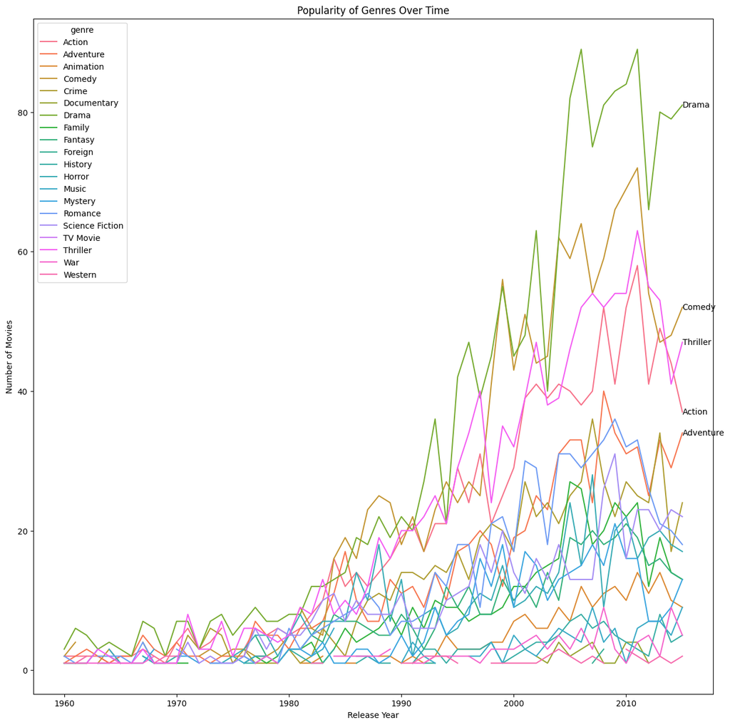

```python
# Splitting genres column into separate genre columns
df = pd.concat([df, df['genres'].str.split('|', expand=True)], axis=1)

# Unpivot genre columns into rows
df = pd.melt(df, id_vars=['release_year'], value_vars=[0,1,2,3,4], value_name='genre').dropna()

# Grouping by release_year and genre, and count the number of movies in each group
genre_counts = df.groupby(['release_year', 'genre']).size().reset_index(name='count')

# Pivot the data to have the genres as columns and the release_year as index
genre_counts_pivot = genre_counts.pivot(index='release_year', columns='genre', values='count')

# Defining a custom color palette with 20 colors
custom_palette = sns.color_palette("husl", 20)

# Creating a line plot using pandas
ax = genre_counts_pivot.plot(kind='line', figsize=(15,15), color=custom_palette)

# Set the plot title and axis labels
ax.set_title('Popularity of Genres Over Time')
ax.set_xlabel('Release Year')
ax.set_ylabel('Number of Movies')

# Finding the 5th highest count for the last year
last_year = genre_counts_pivot.index[-1]
top_genres = genre_counts_pivot.loc[last_year].sort_values(ascending=False)
fifth_highest_count = top_genres.iloc[4]

# Adding text labels to the plot for the top genres in the last year
for genre in top_genres.index:
    count = genre_counts_pivot.loc[last_year, genre]
    if count >= fifth_highest_count:
        ax.text(last_year, count, genre, ha='left', va='center')

# Showing the plot
plt.show()



###The graph shows that Drama, followed by comedy, thriller, action and adventure are the genders most watched nowadays.
###You can see there's changes of the most popular genre accordint to the year
###Audience preference has changed
```

### Research Question 4: Is there a Correlation between Revenue and Popularity?

```python
# Dropping rows with null values in the 'revenue' and 'popularity' columns
df = df.dropna(subset=['revenue_adj', 'popularity'])

# Calculating the correlation coefficient
corr_coef = df['revenue_adj'].corr(df['popularity'])

# Printing the correlation coefficient
print(corr_coef)

#moderate positive correlation between revenue and popularity
```

```
0.5467636119891278
```

### Research Question 5: Is there a relationship between budget and revenue_adj?

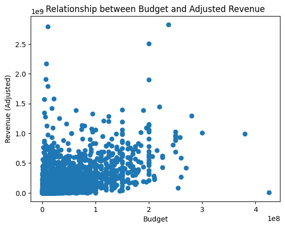

```python
# Converting the 'revenue_adj' and 'budget' columns to numeric data types
df['revenue_adj'] = pd.to_numeric(df['revenue_adj'], errors='coerce')
df['budget'] = pd.to_numeric(df['budget'], errors='coerce')

# Dropping rows with null values in the 'revenue_adj' and 'budget' columns
df = df.dropna(subset=['revenue_adj', 'budget'])

#scatter plot of 'budget' vs 'revenue_adj'
plt.scatter(df['budget'], df['revenue_adj'])
plt.xlabel('Budget')
plt.ylabel('Revenue (Adjusted)')
plt.title('Relationship between Budget and Adjusted Revenue')
plt.show()

#budget has a higher correlation with revenue adj compared to the popularity of the movies
```

## Conclusions

Although our dataset has more than 10,000 rows it's insufficient to draw precise conclusions because:

1. Majority of the data columns are irrelevant for the analysis
2. There's a lot of NaN values. A possible solution would be re-do a web scrapping for a better data quality or prepare data from a different source than the one we have.
3. As seen in the revenue and budget variables, there's a lot of 0-valued data, and after the cleaning step the data gets really small and possibly not representative.
4. Besides poor data quality, one concern part would be that the data is outdated for the main variables, it should include at least streaming services.

### Conclusions from the analysis performed:

1. The most famous actor is Robert de Nirto with 52 original movies.
2. Revenuew, budget and popularity have moderate to high correlation. Bein budget and revenue the most positivly correlated.
3. Drama, followed by comedy, thriller, action and adventure are the genders most watched nowadays. There's changes of the most popular genre accordint to the year, and audience preference has changed as well.
4. Budget has a higher correlation with revenue adj compared to the popularity of the movies.